# Data Exploration & Preparation

Prof. Murali Shanker (@mshanker1) - Advisor

Nick (@odintech3)

Spandana (@spandanasudalagunta)

Tina (@davinia1991)

```r
library("dplyr")
library("magrittr")
library("readxl")
library("ggplot2")
```

# Wells Fargo’s Campus Analytics Challenge: Live Green and Live Happy

One of Wells Fargo’s priorities is to promote environmental sustainability, which includes accelerating the transition to a low-carbon economy. Taking individual actions can encourage collective responsibility to help achieve this. Using machine learning, create a data product to help individuals optimize the balance between their carbon footprint and quality of life. The data gives a peek into the lives of 1,000 individuals who rated several everyday activities (taking a long shower, driving a car, etc.) on a scale of 1-100 based on how important those activities are to their daily lives.

# Objective

The goal of this project is to create a machine learning algorithm that minimizes carbon footprint for each customer while maintaining their total quality of life.

Loading the data into R where sheet1 has the information regrading the individuals and their consumption and sheet2 has information about the carbon footprint for each activity.

```r
sheet1 <- read_excel(
  "data/dataset.xlsx",
  sheet = "Individuals",
  range = "A1:P27055"
)
sheet2 <- read_excel(
  "data/dataset.xlsx",
  sheet = "Carbon Footprint",
  range = "A2:N29"
)
```

Below we have a summary of sheet 1 from the excel dataset (excluding sources) to get the summary of the data we are dealing with.

```r
sheet1 %>%
  select(-sources) %>%
  summary(sheet1)
```

```
     Indnum           Group         Activity            Units            Consumption     Quality_of_Life_Importance__1_10
 Min.   :   1.0   Min.   :1.000   Length:27054       Length:27054       Min.   :  -5.0   Min.   : 4.00
 1st Qu.: 251.0   1st Qu.:2.000   Class :character   Class :character   1st Qu.:   4.0   1st Qu.:22.00
 Median : 501.5   Median :3.000   Mode  :character   Mode  :character   Median :  14.0   Median :41.00
 Mean   : 501.5   Mean   :3.593                                         Mean   : 206.9   Mean   :42.89
 3rd Qu.: 752.0   3rd Qu.:5.000                                         3rd Qu.:  34.0   3rd Qu.:54.00
 Max.   :1002.0   Max.   :6.000                                         Max.   :3997.0   Max.   :98.00
                                                                        NA's   :9359     NA's   :6766
```

We are trying to look at the data for individual 1

```r
sheet1 %>%
  select(-sources) %>%
  filter(Indnum == 1) %>%
  head()
```

| Indnum | Group | Activity | Units | Consumption | Quality_of_Life_Importance__1_10 |
| --- | --- | --- | --- | --- | --- |
| 1 | 1 | Household heating => 70F | hours | 2 | 88 |
| 1 | 1 | Household heating < 70F | hours | 10 | 85 |
| 1 | 1 | Use of heat pump | hours | NA | 50 |
| 1 | 1 | Use of air conditioner | hours | 20 | 45 |
| 1 | 2 | shower - short | count | 5 | 98 |
| 1 | 2 | shower - long (> 3 min) | count | 30 | 74 |

# Data Cleaning

After reviewing the data we have noticed a lot of missing values. we are assuming that the `NA` values are present in the data because the individual didnot have any consumption for the activity and did not give any rating for the quality of life. we are replacing all `NA` values in sheet 1 with 0.

```r
sheet1[is.na(sheet1)] <- 0
sheet1 %>%
  head()
```

| Indnum | Group | Activity | Units | Consumption | Quality_of_Life_Importance__1_10 | solar_powered_water_heater | gas_water_heater | electric_water_heater_peak_hour | electric_water_heater_off_peak | gas | natural_gas | hybrid | electric_peak_hours | electric_off_peak_hours | jetfuel |
| --- | --- | --- | --- | --- | --- | --- | --- | --- | --- | --- | --- | --- | --- | --- | --- |
| 1 | 1 | Household heating => 70F | hours | 2 | 88 | 0 | 0 | 0 | 0 | 0 | 1 | 0 | 0 | 0 | 0 |
| 1 | 1 | Household heating < 70F | hours | 10 | 85 | 1 | 1 | 0 | 0 | 0 | 1 | 0 | 0 | 0 | 0 |
| 1 | 1 | Use of heat pump | hours | 0 | 50 | 0 | 0 | 0 | 0 | 0 | 0 | 0 | 0 | 0 | 0 |
| 1 | 1 | Use of air conditioner | hours | 20 | 45 | 0 | 0 | 0 | 0 | 0 | 0 | 0 | 0 | 0 | 0 |
| 1 | 2 | shower - short | count | 5 | 98 | 0 | 0 | 0 | 0 | 0 | 0 | 0 | 0 | 0 | 0 |
| 1 | 2 | shower - long (> 3 min) | count | 30 | 74 | 0 | 0 | 0 | 0 | 0 | 0 | 0 | 0 | 0 | 0 |

Replacing all the all `NA` values in sheet2 with 0

```r
sheet2[is.na(sheet2)] <- 0
sheet2 %>%
  head()
```

| X__1 | Activity | Per | solar_powered_water_heater | gas_water_heater | electric_water_heater_peak_hour | electric_water_heater_off_peak | gas | natural_gas | jetfuel | waste management | hybrid | electric_peak_hours | electric_off_peak_hours |
| --- | --- | --- | --- | --- | --- | --- | --- | --- | --- | --- | --- | --- | --- |
| 1 | Household heating => 70F | hour | 0.0e+00 | 0.000000 | 0.000000 | 0.000000 | 0 | 0.000436 | 0 | 0 | 0 | 0.000650 | 0.000542 |
| 2 | Household heating < 70F | hour | 0.0e+00 | 0.000000 | 0.000000 | 0.000000 | 0 | 0.000872 | 0 | 0 | 0 | 0.000923 | 0.000901 |
| 3 | Use of heat pump | hour | 0.0e+00 | 0.000000 | 0.000000 | 0.000000 | 0 | 0.001074 | 0 | 0 | 0 | 0.001229 | 0.001188 |
| 4 | Use of air conditioner | hour | 0.0e+00 | 0.000000 | 0.000000 | 0.000000 | 0 | 0.000598 | 0 | 0 | 0 | 0.007980 | 0.000721 |
| 5 | shower - short | activity | 1.2e-05 | 0.000102 | 0.000232 | 0.000199 | 0 | 0.000000 | 0 | 0 | 0 | 0.000000 | 0.000000 |
| 6 | shower - long (> 3 min) | activity | 1.7e-05 | 0.000149 | 0.000354 | 0.000312 | 0 | 0.000000 | 0 | 0 | 0 | 0.000000 | 0.000000 |

Converting the negative values in consumption to positive values.

```r
sheet1 <- sheet1 %>%
  mutate_at(.vars = vars(Consumption), .funs = funs(abs))
summary(sheet1)
```

```
     Indnum           Group         Activity            Units            Consumption     Quality_of_Life_Importance__1_10
 Min.   :   1.0   Min.   :1.000   Length:27054       Length:27054       Min.   :   0.0   Min.   : 0.00
 1st Qu.: 251.0   1st Qu.:2.000   Class :character   Class :character   1st Qu.:   0.0   1st Qu.: 0.00
 Median : 501.5   Median :3.000   Mode  :character   Mode  :character   Median :   4.0   Median :28.00
 Mean   : 501.5   Mean   :3.593                                         Mean   : 135.3   Mean   :32.16
 3rd Qu.: 752.0   3rd Qu.:5.000                                         3rd Qu.:  21.0   3rd Qu.:49.00
 Max.   :1002.0   Max.   :6.000                                         Max.   :3997.0   Max.   :98.00
 solar_powered_water_heater gas_water_heater  electric_water_heater_peak_hour electric_water_heater_off_peak
 Min.   :0.00000            Min.   :0.00000   Min.   :0.00000                 Min.   :0.00000
 1st Qu.:0.00000            1st Qu.:0.00000   1st Qu.:0.00000                 1st Qu.:0.00000
 Median :0.00000            Median :0.00000   Median :0.00000                 Median :0.00000
 Mean   :0.03245            Mean   :0.04059   Mean   :0.03153                 Mean   :0.03645
 3rd Qu.:0.00000            3rd Qu.:0.00000   3rd Qu.:0.00000                 3rd Qu.:0.00000
 Max.   :1.00000            Max.   :1.00000   Max.   :1.00000                 Max.   :1.00000
      gas          natural_gas          hybrid        electric_peak_hours electric_off_peak_hours    jetfuel
 Min.   :0.0000   Min.   :0.00000   Min.   :0.00000   Min.   :0.00000     Min.   :0.00000         Min.   :0.00000
 1st Qu.:0.0000   1st Qu.:0.00000   1st Qu.:0.00000   1st Qu.:0.00000     1st Qu.:0.00000         1st Qu.:0.00000
 Median :0.0000   Median :0.00000   Median :0.00000   Median :0.00000     Median :0.00000         Median :0.00000
 Mean   :0.1245   Mean   :0.07407   Mean   :0.01357   Mean   :0.01172     Mean   :0.05556         Mean   :0.01804
 3rd Qu.:0.0000   3rd Qu.:0.00000   3rd Qu.:0.00000   3rd Qu.:0.00000     3rd Qu.:0.00000         3rd Qu.:0.00000
 Max.   :1.0000   Max.   :1.00000   Max.   :1.00000   Max.   :1.00000     Max.   :1.00000         Max.   :1.00000
```

Below we are filling the carbon footprint for each activity, where ever the source has 1 the corresponding carbonfootprint value is filled.

```r
for (activity in activities) {
  cf_activity <- as.vector(unlist(sheet2[sheet2$Activity == activity, sources]))
  activity_sources <- sheet1[sheet1$Activity == activity, sources]
  result <- data.frame(mapply(`*`, activity_sources, cf_activity, SIMPLIFY = F))

  sheet1[sheet1$Activity == activity, sources] <- result
}
```

Below is a graph showing the sum of consumptions for each activity in their respective units.

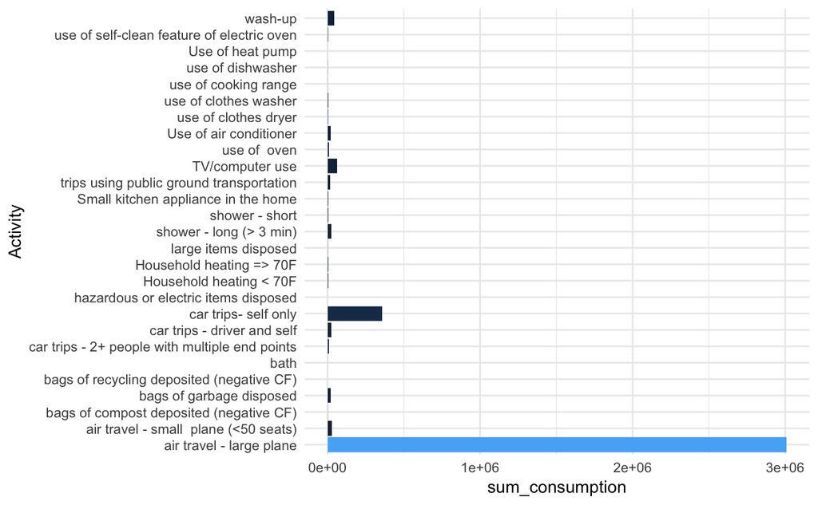

```r
sheet1 %>%
  select(Activity, Consumption) %>%
  group_by(Activity) %>%
  summarise(sum_consumption = sum(Consumption)) %>%
  arrange(desc(sum_consumption)) %>%
  ggplot(aes(x = Activity, y = sum_consumption, fill = sum_consumption)) +
  geom_bar(stat = 'identity') +
  coord_flip() +
  theme_minimal() +
  guides(fill = F)
```

```r
NA
```

Below table shows the maximum and minimum units of consumption for each activity.

```r
sheet1 %>%
  select(Activity, Consumption) %>%
  group_by(Activity) %>%
  summarise(max_consumption = max(Consumption), min_consumption = min(Consumption))
```

| Activity | max_consumption | min_consumption |
| --- | --- | --- |
| air travel - large plane | 3997 | 2003 |
| air travel - small plane (<50 seats) | 700 | 0 |
| bags of compost deposited (negative CF) | 8 | 0 |
| bags of garbage disposed | 28 | 17 |
| bags of recycling deposited (negative CF) | 8 | 0 |
| bath | 7 | 0 |
| car trips - 2+ people with multiple end points | 30 | 0 |
| car trips - driver and self | 40 | 10 |
| car trips- self only | 464 | 258 |
| hazardous or electric items disposed | 3 | 0 |

[output cut: 17 more lines]

# Data Preparation

In the data preparation stage we have created two new variables TCF = Total carbon footprint for each individual per activity and TrQL = product of consumption and quality of life for each individual per activity.

```r
sheet1 <- sheet1 %>%
  mutate(
    TCF = rowSums(.[,sources]),
    TrQL = Consumption * Quality_of_Life_Importance__1_10)
head(sheet1)
```

| Indnum | Group | Activity | Units | Consumption | Quality_of_Life_Importance__1_10 | solar_powered_water_heater | gas_water_heater | electric_water_heater_peak_hour | electric_water_heater_off_peak | gas | natural_gas | hybrid | electric_peak_hours | electric_off_peak_hours | jetfuel | TCF | TrQL |
| --- | --- | --- | --- | --- | --- | --- | --- | --- | --- | --- | --- | --- | --- | --- | --- | --- | --- |
| 1 | 1 | Household heating => 70F | hours | 2 | 88 | 0 | 0 | 0 | 0 | 0 | 0.000436 | 0 | 0 | 0 | 0 | 0.000436 | 176 |
| 1 | 1 | Household heating < 70F | hours | 10 | 85 | 0 | 0 | 0 | 0 | 0 | 0.000872 | 0 | 0 | 0 | 0 | 0.000872 | 850 |
| 1 | 1 | Use of heat pump | hours | 0 | 50 | 0 | 0 | 0 | 0 | 0 | 0.000000 | 0 | 0 | 0 | 0 | 0.000000 | 0 |
| 1 | 1 | Use of air conditioner | hours | 20 | 45 | 0 | 0 | 0 | 0 | 0 | 0.000000 | 0 | 0 | 0 | 0 | 0.000000 | 900 |
| 1 | 2 | shower - short | count | 5 | 98 | 0 | 0 | 0 | 0 | 0 | 0.000000 | 0 | 0 | 0 | 0 | 0.000000 | 490 |
| 1 | 2 | shower - long (> 3 min) | count | 30 | 74 | 0 | 0 | 0 | 0 | 0 | 0.000000 | 0 | 0 | 0 | 0 | 0.000000 | 2220 |